# Paul Tol’s Color Schemes

N. Frerebeau

2023-08-21

```r
library(khroma)
```

## Introduction

Tol (2021) offers carefully chosen schemes, ready for each type of data, with colors that are:

- Distinct for all people, including color-blind readers,
- Distinct from black and white,
- Distinct on screen and paper,
- Matching well together.

All the scales presented in Paul Tol’s technical note (issue 3.2, 2021-08-18) are implemented here, for use with base R **graphics** or [**ggplot2**](https://ggplot2.tidyverse.org/).

## Qualitative data

According to Paul Tol’s technical note, the *bright*, *contrast*, *vibrant* and *muted* color schemes are color-blind safe.

The *light* color scheme is reasonably distinct for both normal or color-blind vision and is intended to fill labelled cells.

The *pale* and *dark* schemes are not very distinct in either normal or color-blind vision and should be used as a text background or to highlight a cell in a table.

The qualitative color schemes must be used as given (no interpolation): colors are picked up to the maximum number of supported values. Refer to the original document for details about the recommended uses (see references).

[output not shown]

### *bright*

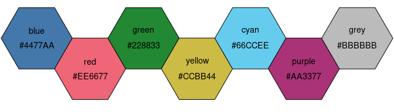

```r
bright <- color("bright")
plot_scheme(bright(7), colours = TRUE, names = TRUE, size = 0.9)
```

### *high contrast*

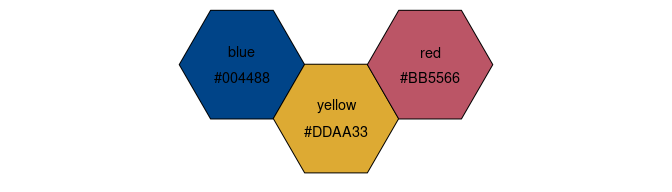

```r
highcontrast <- color("high contrast")
plot_scheme(highcontrast(3), colours = TRUE, names = TRUE, size = 0.9)
```

### *vibrant*

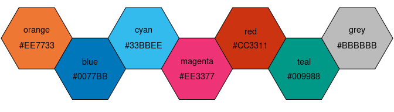

```r
vibrant <- color("vibrant")
plot_scheme(vibrant(7), colours = TRUE, names = TRUE, size = 0.9)
```

### *muted*

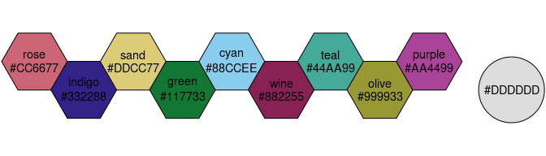

```r
muted <- color("muted")
plot_scheme(muted(9), colours = TRUE, names = TRUE, size = 0.9)
```

### *medium contrast*

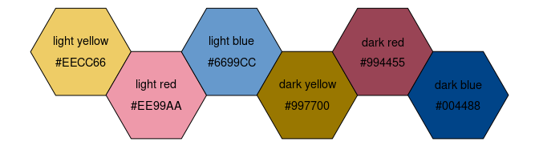

```r
mediumcontrast <- color("medium contrast")
plot_scheme(mediumcontrast(6), colours = TRUE, names = TRUE, size = 0.9)
```

### *pale* and *dark*

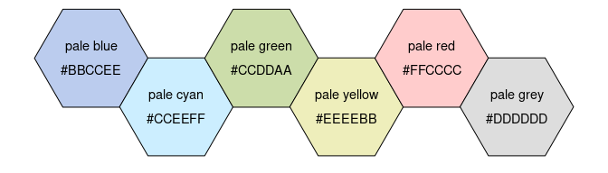

```r
pale <- color("pale")
plot_scheme(pale(6), colours = TRUE, names = TRUE, size = 0.9)
```

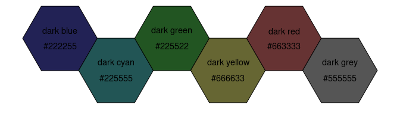

```r
dark <- color("dark")
plot_scheme(dark(6), colours = TRUE, names = TRUE, size = 0.9)
```

### *light*

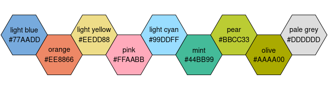

```r
light <- color("light")
plot_scheme(light(9), colours = TRUE, names = TRUE, size = 0.9)
```

## Diverging data

If more colors than defined are needed from a given scheme, the color coordinates are linearly interpolated to provide a continuous version of the scheme.

| Scheme | Num. of colors | Bad data |
| --- | --- | --- |
| `sunset` | 11 | #FFFFFF |
| `BuRd` | 9 | #FFEE99 |
| `PRGn` | 9 | #FFEE99 |

### *sunset*

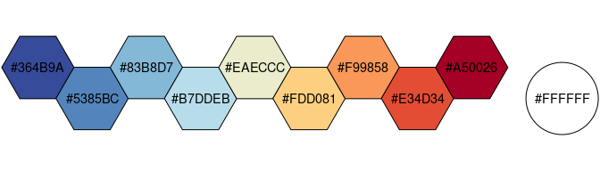

```r
sunset <- color("sunset")
plot_scheme(sunset(9), colours = TRUE, size = 0.9)
```

### *BuRd*

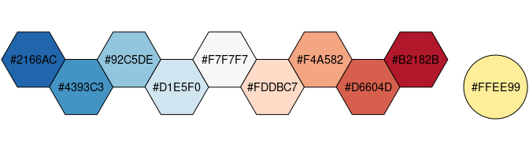

```r
BuRd <- color("BuRd")
plot_scheme(BuRd(9), colours = TRUE, size = 0.9)
```

### *PRGn*

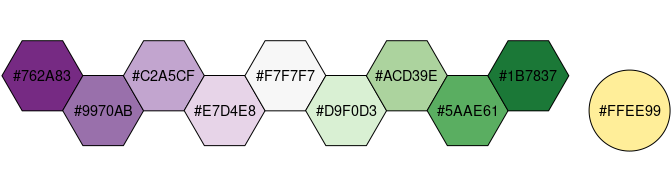

```r
PRGn <- color("PRGn")
plot_scheme(PRGn(9), colours = TRUE, size = 0.9)
```

## Sequential data

If more colors than defined are needed from a given scheme, the color coordinates are linearly interpolated to provide a continuous version of the scheme, with the exception of the *discrete rainbow* scheme (see below).

| Scheme | Num. of colors | Bad data |
| --- | --- | --- |
| `YlOrBr` | 9 | #888888 |
| `iridescent` | 23 | #999999 |
| `discrete rainbow` | 23 | #777777 |
| `smooth rainbow` | 34 | #666666 |

### *YlOrBr*

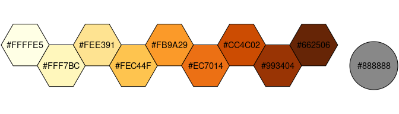

```r
YlOrBr <- color("YlOrBr")
plot_scheme(YlOrBr(9), colours = TRUE, size = 0.9)
```

### *iridescent*

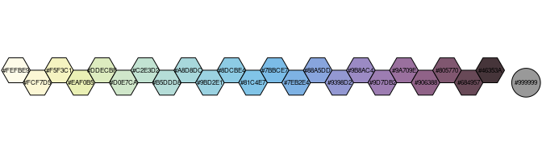

```r
iridescent <- color("iridescent")
plot_scheme(iridescent(23), colours = TRUE, size = 0.5)
```

### *rainbow*

As a general rule, ordered data should not be represented using a rainbow scheme. There are three main arguments against such use (Tol 2021):

- The spectral order of visible light carries no inherent magnitude message.
- Some bands of almost constant hue with sharp transitions between them, can be perceived as jumps in the data.
- Color-blind people have difficulty distinguishing some colors of the rainbow.

If such use cannot be avoided, Paul Tol’s technical note provides two color schemes that are reasonably clear in color-blind vision. To remain color-blind safe, these two schemes must comply with the following conditions:

**discrete rainbow**

This scheme must not be interpolated.

**smooth rainbow**

This scheme does not have to be used over the full range (Tol 2021 suggests starting at purple).

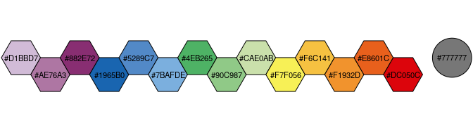

```r
discrete_rainbow <- color("discrete rainbow")
plot_scheme(discrete_rainbow(14), colours = TRUE, size = 0.7)
```

When using the *smooth rainbow* scheme:

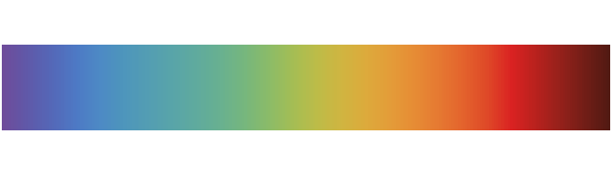

```r
smooth_rainbow <- color("smooth rainbow")

## Start at purple instead of off-white
plot(smooth_rainbow(256, range = c(0.25, 1)))
```

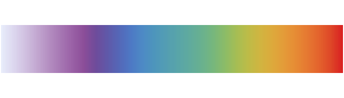

```r
## End at red instead of brown
plot(smooth_rainbow(256, range = c(0, 0.9)))
```

## Diagnostic maps

### Qualitative color schemes

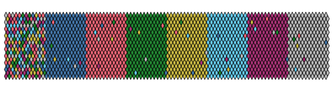

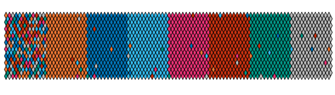

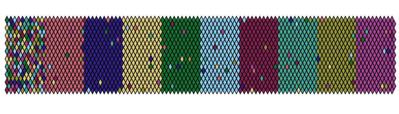

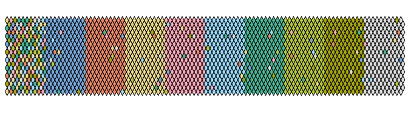

### Diverging schemes

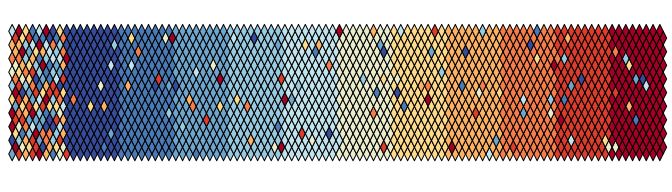

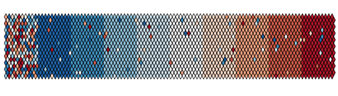

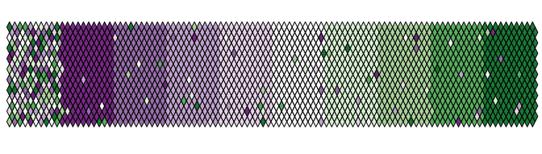

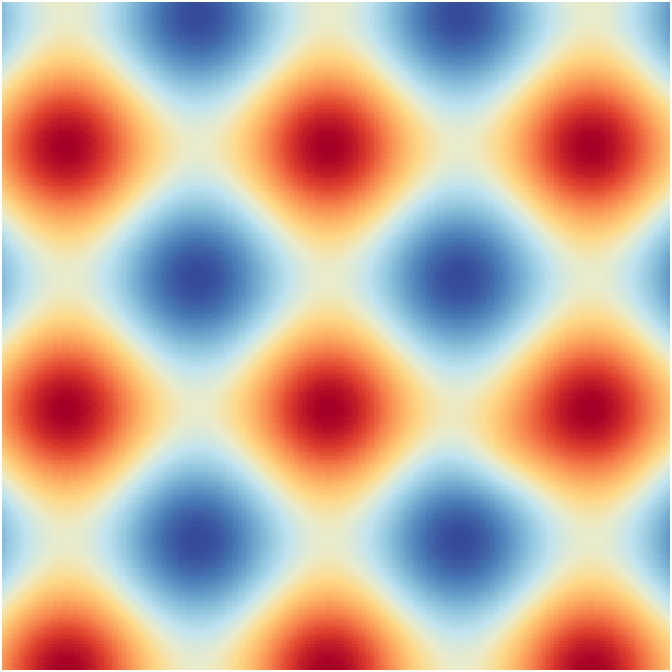

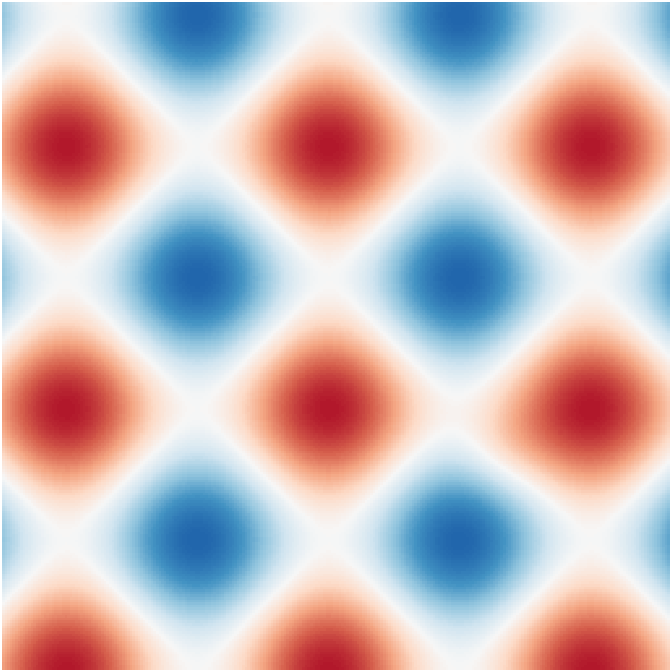

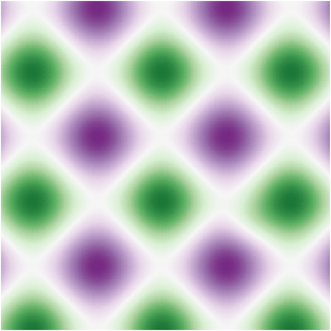

Diagnostic maps for the sunset, BuRd and PRGn diverging color schemes.